# project-2

### **Home buying trends in Australia**

This project will try and investigate the home buying trends in Australia. It will provide details on state-wide buying outcomes and its trend. The analysis will also share the trend on fist-time-home-buyers. Finally it will try and hypothise any corelation between property market volatility and COVID with NSW as a reference state.

The project will cover the following topics:

Summary of contents:

1. Introduction
2. Summary
3. Data Inspection and Cleaning
4. Analysis and Answers to Questions
5. Conclusions and Discussion
6. Future Analysis
7. References

### **1. Introduction**

Australia in the last 30 years has seen tremendous value assimilation on property. Our economy has been called as the “Goldie Locks” economy, where external and global indexes have had minimal impact. Exports of coal, iron ore and other natural resources have been fuelling the economy when world economy was under pressure in the years of 2000, 2008, 2018 (onwards), etc. This has clearly reflected in Australia’s purchasing parity. Strong economy, stable governments, robust exports, immigration support foreign policy has also provided push to the home purchasing in Australia.

Strong performances on home ownership and positive gearing over the last few decades has also been one of our strong indicators of economy. This paper reveals some of these trends in the last couple of decades. In 2019, the globe saw something which will would change our interactions with technology and would define how we spend our family times together. The global pandemic forced us to re-think approximately 200 years of way-of-working and skewed the work-life balance. Although the pandemic severely impacted industries such as Travel and Transportation, Manufacturing, Tourism, Retail, there were many other industries which took advantage of this pandemic. Retail giants quickly endorsed home-delivery. Multiple industry workers, students, and families; reluctantly first settled into the routine of work-from-home.

The ask for work-study-from-home meant a significant populace within Australia started thinking about property purchase. We would see in this paper, that there is sharp rise of first home buyers from 2020. Along with government policies of lower borrowing interest rates many first-home buyers took the plunge of buying property across Australia. We have seen these numbers consistently across all urban areas in Australia. This demand also had a cyclic impact on price increase, new property development, land-only sale and unit sales.

COVID could be only one reason for the price increase. We are showcasing this relationship with multiple data sources, i.e., from Australia Bureau of Statistics and focussing on NSW as a state to show the sharp rise of the various first-home buyers from NSW data site. Links to various datasets are shared below.

**Questions to be answered**

1. Has there been an increase in Australia borrowing during the pandemic year?
2. Has there been a change in the borrowing behaviour during pandemic time?
3. Which state sells the maximum Units?
4. Which state borrows the maximum?
5. Has there been a significant rise in property market in NSW during recent years?
6. Was there any corelation of a COVID spike in terms of the borrowing in NSW?

**Data Files Used**

**560103** This file is imported in dataframe called new_borrow_df with columns including Unit Sales and Borrowing costs (in millions) for categories to include as land only, new dwellings, existing dwelling, alterations and repairs borrowing. We will use this file to categorise and represent answers to multiple questions wrt borrowing capability and state-wide representation. This excludes re-financing.

**NSW_COVID** This file is downloaded from NSW health site (link provided in references) and represents confirmed COVID cases in NSW, for every post code. We would represent the highest confirmed COVID cases for each post code. This dataframe is loaded on NSW_COVID_df and is merged with state_wide_df, giving us a unique perspective of the impact of COVID on the buying behavious in NSW state.

**Note**: this file is over 122,000 row and takes a while to load on Ed. I have had experiences where the kernel needed restarting, so please be patient and if required, restart the kernel if prompted.

### **2. Summary**

We have seen the trend over a 20 year period, although the multiple files and data points, clearly indicates that there has been a significant spike in first-time-home-buyers during the COVID months. The data also let us interpret the buying trends across various states in Australis during this time.

It is also a solid fact that there has been a high amount of borrowing for Renovation and Alteration, which has not been seen as a trend for last 20 years. From this trend, it could be seen that COVID has certainly driven Australians passion on home renovation.

### **3. Data inspection and cleaning**

```python
    # Start by importing required modules
import pandas as pd
import matplotlib.pyplot as plt
import seaborn as sns
```

```python
# Import the required data
new_borrow_df = pd.read_excel('560103.xlsx', sheet_name='Data1')
state_wide_df = pd.read_excel('560125.xlsx', sheet_name='Data1')
NSW_COVID_df = pd.read_excel('NSW_COVID.xlsx')

print(new_borrow_df.columns.is_unique)
print(new_borrow_df.shape)
```

```
True
(236, 17)
```

Three files are being imported here and loaded on respective dataframe.

The next three code visualises the loaded dataframes and the santicity of the data being used for the analysis.

```python
# visualising new_borrow_df with all the columns
new_borrow_df
```

|  | Time | Initial | New_Construction_Unit | Pre-erected_Unit | Existing_Dwelling_Unit | Land_Only_Unit | Alterations_Repairs_Unit | External_Refinancing_Unit | Internal_Refinancing_Unit | Unnamed: 9 | New_Construction_Cost | Pre-erected_Cost | Existing_Dwelling_Cost | Land_Only_Cost | Alterations_Repairs_Cost | External refinancing | Internal refinancing |
| --- | --- | --- | --- | --- | --- | --- | --- | --- | --- | --- | --- | --- | --- | --- | --- | --- | --- |
| 0 | 2002-07-01 | NaN | 3983 | 1251 | 27900 | NaN | NaN | 12195 | NaN | 6025.1 | 713.2 | 223.8 | 4615.8 | 267.8 | 1694.3 | NaN | NaN |
| 1 | 2002-08-01 | NaN | 3407 | 1149 | 26325 | NaN | NaN | 11228 | NaN | 5986.3 | 660.2 | 227.6 | 4609.6 | 277.3 | 1691.9 | NaN | NaN |
| 2 | 2002-09-01 | NaN | 3055 | 1136 | 24828 | NaN | NaN | 10516 | NaN | 6037.0 | 642.8 | 230.7 | 4646.0 | 288.6 | 1701.6 | NaN | NaN |
| 3 | 2002-10-01 | NaN | 3166 | 1142 | 27242 | NaN | NaN | 11781 | NaN | 6192.3 | 629.0 | 221.5 | 4778.3 | 319.5 | 1763.9 | NaN | NaN |
| 4 | 2002-11-01 | NaN | 2874 | 1313 | 26441 | NaN | NaN | 11408 | NaN | 6260.3 | 661.4 | 250.7 | 4775.4 | 336.4 | 1805.8 | NaN | NaN |
| ... | ... | ... | ... | ... | ... | ... | ... | ... | ... | ... | ... | ... | ... | ... | ... | ... | ... |
| 231 | 2021-10-01 | 38112.0 | 4299 | 2286 | 26149 | 2721.0 | 2657.0 | 20515 | 13420.0 | 19807.1 | 2145.7 | 1212.7 | 15121.1 | 475.2 | 10249.9 | NaN | NaN |
| 232 | 2021-11-01 | 44306.0 | 4712 | 2619 | 30968 | 2973.0 | 3034.0 | 22002 | 15144.0 | 21284.5 | 2328.9 | 1249.0 | 16262.3 | 561.0 | 9993.9 | NaN | NaN |
| 233 | 2021-12-01 | 44611.0 | 4602 | 2885 | 31074 | 2999.0 | 3051.0 | 21538 | 14193.0 | 22406.5 | 2262.3 | 1358.2 | 17345.1 | 539.3 | 10108.1 | NaN | NaN |
| 234 | 2022-01-01 | 33340.0 | 3325 | 1821 | 23956 | 2009.0 | 2229.0 | 14788 | 10255.0 | 22588.4 | 2176.3 | 1362.8 | 17711.7 | 471.8 | 8993.9 | NaN | NaN |
| 235 | 2022-02-01 | 33595.0 | 3743 | 1852 | 22778 | 2197.0 | 3025.0 | 17110 | 13263.0 | 21532.8 | 2244.6 | 1265.0 | 16616.1 | 524.8 | 9985.0 | NaN | NaN |

236 rows × 17 columns

```python
#visualising state_wide_df with all the columns
state_wide_df
```

|  | Series ID | Australia_Unit | NSW_Unit | VIC_Unit | QLD_Unit | SA_Unit | WA_Unit | TAS_Unit | NT_Unit | ACT_Unit | Australia_Cost | NSW_Cost | VIC_Cost | QLD_Cost | SA_Cost | WA_Cost | TAS_Cost | NT_Cost | ACT_Cost |
| --- | --- | --- | --- | --- | --- | --- | --- | --- | --- | --- | --- | --- | --- | --- | --- | --- | --- | --- | --- |
| 0 | 2019-07-01 | 609 | 261 | 188 | 92 | 26 | 19 | NaN | NaN | 17.0 | 270.0 | 135.2 | 79.0 | 31.1 | 8.6 | 7.1 | NaN | NaN | 7.9 |
| 1 | 2019-08-01 | 585 | 218 | 159 | 101 | 32 | 46 | NaN | NaN | 12.0 | 269.2 | 120.0 | 69.5 | 35.8 | 12.2 | 15.0 | NaN | NaN | 7.3 |
| 2 | 2019-09-01 | 502 | 224 | 141 | 65 | 22 | 31 | NaN | NaN | 10.0 | 236.0 | 122.7 | 65.5 | 21.5 | 6.9 | 12.7 | NaN | NaN | 3.9 |
| 3 | 2019-10-01 | 558 | 232 | 131 | 78 | 51 | 45 | NaN | NaN | 16.0 | 267.2 | 134.5 | 62.2 | 32.4 | 17.0 | 14.2 | NaN | NaN | 5.9 |
| 4 | 2019-11-01 | 552 | 214 | 173 | 80 | 26 | 35 | 6.0 | 4.0 | 14.0 | 270.9 | 127.1 | 83.9 | 33.4 | 7.8 | 10.4 | 1.6 | 1.4 | 5.3 |
| 5 | 2019-12-01 | 546 | 190 | 161 | 96 | 29 | 43 | NaN | NaN | 18.0 | 256.9 | 112.2 | 78.6 | 35.0 | 7.6 | 14.3 | NaN | NaN | 6.9 |
| 6 | 2020-01-01 | 388 | 142 | 112 | 46 | 27 | 37 | NaN | NaN | 14.0 | 177.8 | 80.2 | 49.6 | 17.5 | 8.7 | 13.5 | NaN | NaN | 5.4 |
| 7 | 2020-02-01 | 360 | 122 | 108 | 67 | 19 | 29 | NaN | NaN | 9.0 | 163.7 | 65.9 | 50.2 | 27.5 | 5.4 | 10.0 | NaN | NaN | 2.9 |
| 8 | 2020-03-01 | 434 | 159 | 101 | 90 | 26 | 39 | NaN | NaN | 8.0 | 196.4 | 88.4 | 45.7 | 36.6 | 8.4 | 12.1 | NaN | NaN | 3.1 |
| 9 | 2020-04-01 | 392 | 169 | 96 | 55 | 31 | 28 | NaN | NaN | 9.0 | 199.0 | 97.8 | 54.1 | 20.3 | 11.5 | 11.2 | NaN | NaN | 3.1 |
| 10 | 2020-05-01 | 404 | 156 | 124 | 64 | 28 | 11 | NaN | NaN | 18.0 | 196.0 | 88.4 | 61.4 | 24.5 | 11.1 | 3.4 | NaN | NaN | 6.5 |
| 11 | 2020-06-01 | 491 | 195 | 144 | 88 | 26 | 20 | NaN | NaN | 12.0 | 232.9 | 111.3 | 64.1 | 36.3 | 8.2 | 7.0 | NaN | NaN | 4.5 |
| 12 | 2020-07-01 | 531 | 191 | 145 | 96 | 30 | 50 | NaN | NaN | 13.0 | 245.1 | 106.1 | 71.2 | 37.4 | 11.1 | 12.8 | NaN | NaN | 4.4 |
| 13 | 2020-08-01 | 531 | 210 | 126 | 80 | 38 | 51 | 9.0 | 5.0 | 12.0 | 251.1 | 118.9 | 61.0 | 30.9 | 12.8 | 18.0 | 3.2 | 1.6 | 4.7 |
| 14 | 2020-09-01 | 634 | 252 | 141 | 112 | 34 | 61 | NaN | NaN | 26.0 | 297.9 | 146.9 | 62.3 | 44.7 | 12.4 | 17.8 | NaN | NaN | 12.2 |
| 15 | 2020-10-01 | 590 | 245 | 94 | 112 | 37 | 77 | NaN | NaN | 14.0 | 280.5 | 145.8 | 42.0 | 48.3 | 11.2 | 24.5 | NaN | NaN | 5.9 |
| 16 | 2020-11-01 | 646 | 261 | 135 | 116 | 35 | 61 | 10.0 | 4.0 | 24.0 | 309.2 | 149.9 | 64.5 | 50.9 | 10.4 | 19.0 | 2.7 | 1.4 | 10.4 |
| 17 | 2020-12-01 | 732 | 278 | 202 | 124 | 36 | 57 | NaN | NaN | 27.0 | 351.8 | 154.6 | 98.0 | 53.8 | 12.6 | 18.0 | NaN | NaN | 12.3 |
| 18 | 2021-01-01 | 642 | 203 | 187 | 116 | 25 | 80 | NaN | NaN | 18.0 | 307.4 | 119.2 | 95.8 | 47.4 | 7.9 | 25.9 | NaN | NaN | 7.4 |
| 19 | 2021-02-01 | 657 | 201 | 178 | 115 | 51 | 72 | NaN | NaN | 27.0 | 308.1 | 114.8 | 84.3 | 54.0 | 19.0 | 21.8 | NaN | NaN | 10.4 |
| 20 | 2021-03-01 | 874 | 327 | 223 | 168 | 47 | 84 | NaN | NaN | 11.0 | 440.5 | 204.7 | 108.3 | 71.9 | 16.2 | 29.5 | NaN | NaN | 4.9 |
| 21 | 2021-04-01 | 823 | 287 | 246 | 128 | 48 | 75 | 14.0 | 4.0 | 21.0 | 439.1 | 179.4 | 137.4 | 61.2 | 18.4 | 27.1 | 4.0 | 1.6 | 9.8 |
| 22 | 2021-05-01 | 928 | 336 | 275 | 149 | 39 | 85 | NaN | NaN | 31.0 | 513.1 | 222.3 | 155.5 | 67.3 | 13.2 | 34.6 | NaN | NaN | 15.2 |
| 23 | 2021-06-01 | 1042 | 347 | 324 | 180 | 63 | 78 | NaN | NaN | 32.0 | 550.5 | 217.3 | 177.9 | 80.8 | 26.0 | 26.8 | NaN | NaN | 15.7 |
| 24 | 2021-07-01 | 930 | 319 | 287 | 165 | 50 | 64 | NaN | NaN | 33.0 | 517.6 | 221.8 | 153.7 | 75.5 | 20.0 | 25.5 | NaN | NaN | 16.0 |
| 25 | 2021-08-01 | 915 | 332 | 238 | 181 | 46 | 60 | 14.0 | 4.0 | 40.0 | 524.1 | 239.2 | 137.1 | 85.2 | 17.1 | 21.2 | 4.9 | 1.2 | 18.1 |
| 26 | 2021-09-01 | 844 | 295 | 191 | 175 | 60 | 78 | NaN | NaN | 27.0 | 468.2 | 188.4 | 122.6 | 85.4 | 23.7 | 26.6 | NaN | NaN | 13.4 |
| 27 | 2021-10-01 | 850 | 276 | 213 | 192 | 62 | 71 | 14.0 | NaN | NaN | 478.9 | 188.6 | 126.1 | 98.2 | 25.5 | 24.3 | 5.8 | NaN | NaN |
| 28 | 2021-11-01 | 1025 | 358 | 218 | 225 | 86 | 89 | 12.0 | 4.0 | 33.0 | 580.8 | 240.6 | 142.0 | 110.1 | 31.8 | 31.7 | NaN | NaN | 17.1 |
| 29 | 2021-12-01 | 1006 | 322 | 257 | 235 | 59 | 87 | NaN | NaN | 32.0 | 585.6 | 231.1 | 152.5 | 121.5 | 24.1 | 36.8 | NaN | NaN | 14.4 |
| 30 | 2022-01-01 | 681 | 219 | 185 | 143 | 40 | 62 | NaN | NaN | 17.0 | 377.9 | 144.1 | 106.9 | 70.8 | 18.1 | 21.0 | NaN | NaN | 9.1 |
| 31 | 2022-02-01 | 607 | 192 | 140 | 147 | 52 | 52 | NaN | NaN | 19.0 | 333.7 | 135.4 | 79.5 | 71.4 | 17.3 | 19.4 | NaN | NaN | 8.7 |

```python
# visualising all NSW_COVID_df with defined rowns
NSW_COVID_df
```

|  | postcode | lhd_2010_name | lga_code19 | lga_name19 | confirmed_cases_count | MONTH | YEAR |
| --- | --- | --- | --- | --- | --- | --- | --- |
| 0 | 2071 | Northern Sydney | 14500 | Ku-ring-gai (A) | 1 | 1 | 2020 |
| 1 | 2121 | Northern Sydney | 16260 | Parramatta (C) | 1 | 1 | 2020 |
| 2 | 2134 | Sydney | 11300 | Burwood (A) | 1 | 1 | 2020 |
| 3 | 2033 | South Eastern Sydney | 16550 | Randwick (C) | 1 | 1 | 2020 |
| 4 | 2077 | Northern Sydney | 14000 | Hornsby (A) | 1 | 3 | 2020 |
| ... | ... | ... | ... | ... | ... | ... | ... |
| 122009 | 2877 | Western NSW | 14600 | Lachlan (A) | 3 | 4 | 2022 |
| 122010 | 2880 | Far West | 11250 | Broken Hill (C) | 19 | 4 | 2022 |
| 122011 | 2880 | Far West | 11250 | Broken Hill (C) | 2 | 4 | 2022 |
| 122012 | None | Murrumbidgee | 10650 | Berrigan (A) | 1 | 4 | 2022 |
| 122013 | None | Correctional settings | X999 | Correctional settings | 2 | 4 | 2022 |

122014 rows × 7 columns

The files being imported require a bit of cleansing and ensuring the data is correctly structured for interpretation.

The following corrections are being made for the new_borrow dataframe:

```python
highest_COVID_cases_df = NSW_COVID_df.groupby(['YEAR','MONTH']).agg({'confirmed_cases_count': 'sum'})
```

```python
highest_COVID_cases_df
```

| YEAR | MONTH | confirmed_cases_count |
| --- | --- | --- |
| 2020 | 1 | 4 |
|  | 3 | 2105 |
|  | 4 | 794 |
|  | 5 | 52 |
|  | 6 | 88 |
|  | 7 | 319 |
|  | 8 | 271 |
|  | 9 | 127 |
|  | 10 | 149 |
|  | 11 | 87 |
|  | 12 | 284 |
| 2021 | 1 | 120 |
|  | 2 | 39 |
|  | 3 | 68 |
|  | 4 | 84 |
|  | 5 | 71 |
|  | 6 | 244 |
|  | 7 | 3270 |
|  | 8 | 18923 |
|  | 9 | 34772 |
|  | 10 | 12318 |
|  | 11 | 6530 |
|  | 12 | 130020 |
| 2022 | 1 | 684167 |
|  | 2 | 233091 |
|  | 3 | 524085 |
|  | 4 | 226682 |

There is a large spike during the end of 2021 and beginning of 2022. As the chart shows, we were approx 130,000 cases in NSW, going to 684,000 cases in January. Since then we have dipped, but there was another smaller peak in March of over half a million cases.

**Note:** the April 2022 data is not for the entire month, there are chances that we may actually go to January 2022 numbers.

```python
#drop columns for effective processing of the dataframe
new_borrow_df = new_borrow_df.drop(columns = ['External_Refinancing_Unit', 'Internal_Refinancing_Unit', 'Unnamed: 9', 'External refinancing', 'Internal refinancing', 'Initial'])

#for the two dataframes, replacing missing data with zero value
#new_borrow_df = new_borrow_df.fillna(0)
state_wide_df = state_wide_df.fillna(0)

new_borrow_df['YEAR'] = new_borrow_df['Time'].dt.year
new_borrow_df['MONTH'] = new_borrow_df['Time'].dt.month
new_borrow_df['DAY'] = new_borrow_df['Time'].dt.day

state_wide_df['YEAR'] = state_wide_df['Series ID'].dt.year
state_wide_df['MONTH'] = state_wide_df['Series ID'].dt.month
```

### **4. Analysis and Answers to questions**

**Question 1**: Has there been an increase in Australia borrowing during the pandemic year?

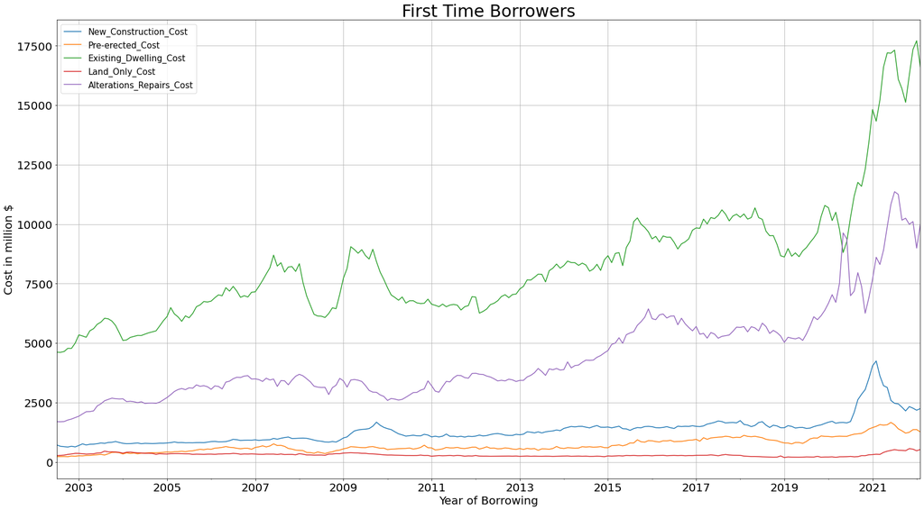

```python
new_borrow_df.plot(
    kind='line',
    fontsize = 20,
    subplots=False,
    sharey=True,
    grid = True,
    x='Time', y=['New_Construction_Cost', 'Pre-erected_Cost', 'Existing_Dwelling_Cost', 'Land_Only_Cost', 'Alterations_Repairs_Cost'],
    legend=True,
    figsize = [27.5,15],
)

plt.title('First Time Borrowers', fontdict={'fontsize': 30})
plt.xlabel('Year of Borrowing', fontdict={'fontsize': 20})
plt.ylabel('Cost in million $',fontdict={'fontsize':20})
plt.legend(loc='best', fontsize='15')
```

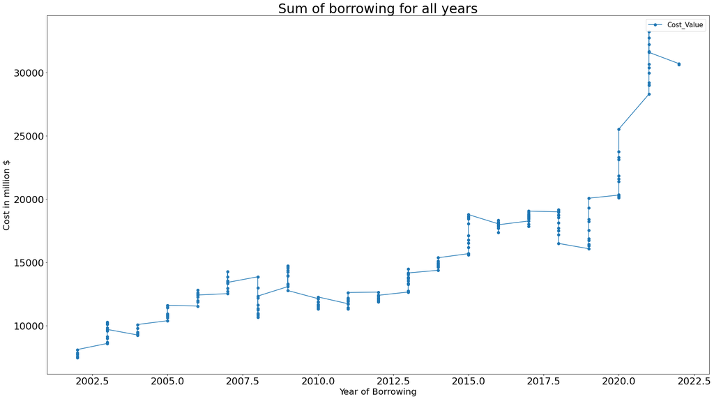

```python
#print the sum of all cost
df6=new_borrow_df
#fill empty cells
df6 = df6.fillna(0)
# sum of all cost values
df6['Cost_Value']=df6['New_Construction_Cost']+df6['Pre-erected_Cost']+df6['Existing_Dwelling_Cost']+df6['Land_Only_Cost']+df6['Alterations_Repairs_Cost']
df6.plot(
    kind='line',
    marker = "o",
    x='YEAR',
    y='Cost_Value',
    figsize = [27, 15],
    fontsize = 22,
)
plt.legend(loc='best')
plt.title('Sum of borrowing for all years', fontdict={'fontsize': 30})
plt.xlabel('Year of Borrowing', fontdict={'fontsize': 20})
plt.ylabel('Cost in million $',fontdict={'fontsize':20})
plt.legend(loc='best', fontsize='15')
```

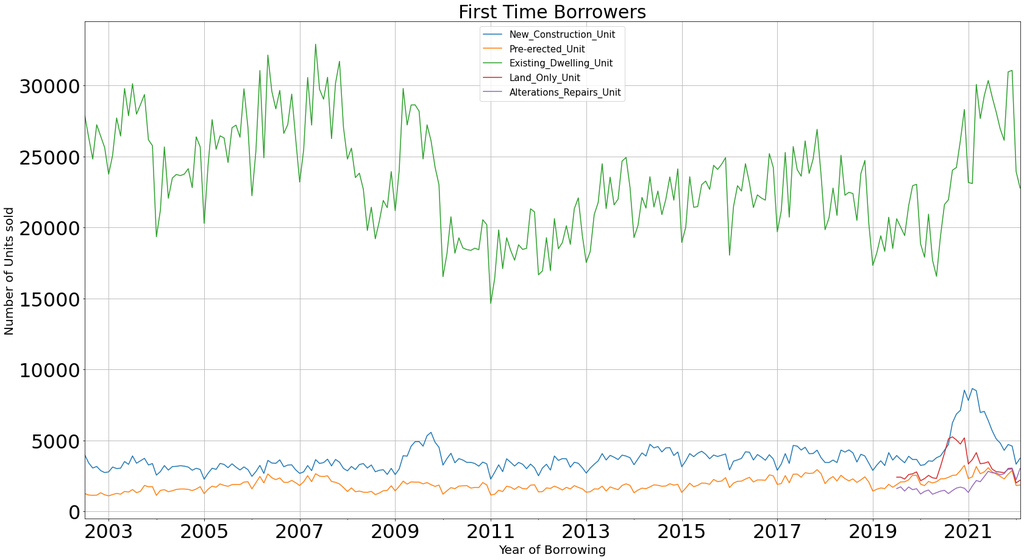

```python
# consideration of all borrowing elements trending to time
new_borrow_df.plot(
    kind='line',
    fontsize = 32,
    subplots=False,
    sharey=True,
    grid = True,
    x='Time', y=['New_Construction_Unit', 'Pre-erected_Unit', 'Existing_Dwelling_Unit', 'Land_Only_Unit', 'Alterations_Repairs_Unit'],
    legend=True,
    figsize = [27.5,15],
)
plt.legend(loc='best')
plt.title('First Time Borrowers', fontdict={'fontsize': 30})
plt.xlabel('Year of Borrowing', fontdict={'fontsize': 20})
plt.ylabel('Number of Units sold',fontdict={'fontsize':20})
plt.legend(loc='best', fontsize='15')
```

**Question 2:** Has there been a change in the borrowing behaviour during pandemic time?

We have plotted a graph for the new_borrow_df with time. From the data point, we clearly see there has been a spike in land_only and alterations_repairs for home buyers. We could determine with a bit of certainity that during COVID time i.e. 2020 onwards, home buyers across the country have taken on projects including land_only and/or alterations and repairs to existing dwelling.

**Note:** is this a testimony of the Australian Spirit? data supports it, but the jury is out there.

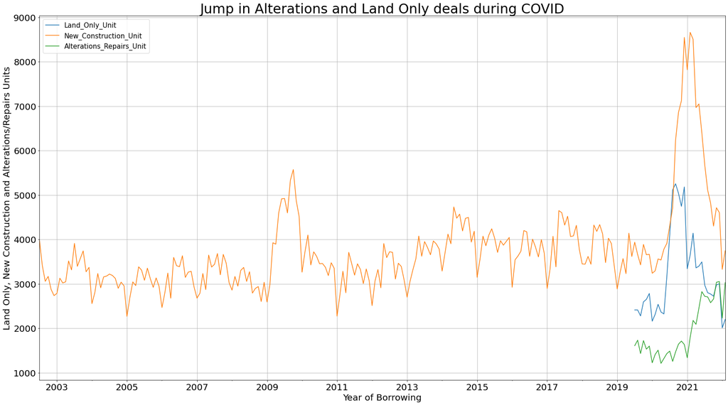

```python
#focus on land only, new construction and alterations units for first time home buyers
new_borrow_df.plot(
    kind='line',
    fontsize = 20,
    subplots=False,
    sharey=True,
    grid = True,
    x='Time', y=['Land_Only_Unit', 'New_Construction_Unit', 'Alterations_Repairs_Unit'],
    legend=True,
    figsize = [27.5, 15],
)
plt.legend(loc='best')
plt.title('Jump in Alterations and Land Only deals during COVID', fontdict={'fontsize': 30})
plt.xlabel('Year of Borrowing', fontdict={'fontsize': 20})
plt.ylabel('Land Only, New Construction and Alterations/Repairs Units' ,fontdict={'fontsize':20})
plt.legend(loc='best', fontsize='15')
```

**Question 3:** Which state sells the maximum Units?

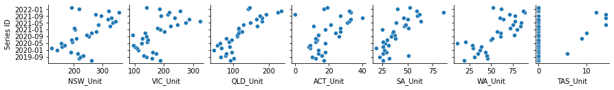

```python
#showcasing state wide unit availability and volatility in property market
state_printing_df=state_wide_df.drop(columns=['TAS_Cost', 'NSW_Cost', 'VIC_Cost', 'QLD_Cost', 'TAS_Cost', 'WA_Cost', 'SA_Cost','Australia_Cost'])

sns.pairplot(
            state_printing_df,
            height = 1.8,
            y_vars = ['Series ID'],
            x_vars = ['NSW_Unit', 'VIC_Unit', 'QLD_Unit', 'ACT_Unit', 'SA_Unit', 'WA_Unit', 'TAS_Unit'],#, 'TAS_Unit'],
            corner = False,
            )
```

**Question 4:** Which state borrows the maximum?

A similar pairplot is used for the cost as we have seen in the Unit plotting above. Here too we clearly see the NSW and Victoria are similarly placed at the top of the pyramid.

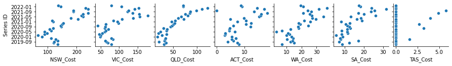

```python
#showcasing state wide cost for borrowing
state_printing_df=state_wide_df.drop(columns=['NSW_Unit', 'VIC_Unit', 'QLD_Unit', 'ACT_Unit', 'SA_Unit', 'WA_Unit','Australia_Cost'])

sns.pairplot(
            state_printing_df,
            height = 1.8,
            y_vars = ['Series ID'],
            x_vars = ['NSW_Cost', 'VIC_Cost', 'QLD_Cost', 'ACT_Cost', 'WA_Cost', 'SA_Cost', 'TAS_Cost'],#, 'TAS_Unit'],
            corner = False,
            )
```

**Question 5:** Has there been a significant rise in property market in NSW during recent years?

Charting the NSW plots for last couple of years, we have seen there is a significant uptake for borrowing of all types of requirement in NSW.

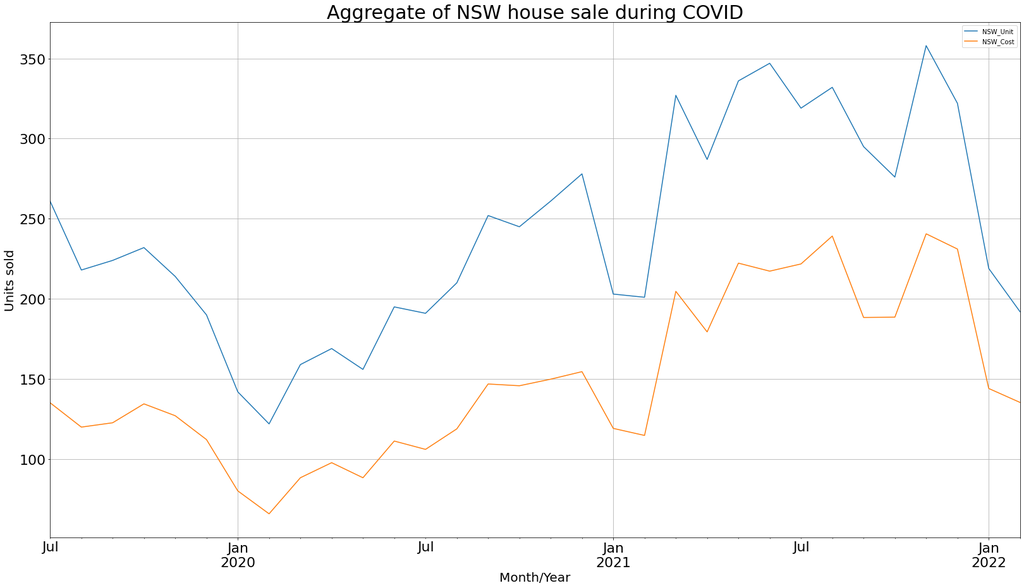

```python
#NSW trend in terms of house volatility and cost
#using state-wide data and cleaning it for appropriate representation

df5 = state_wide_df.drop(columns = ['Australia_Cost', 'Australia_Unit', 'VIC_Unit', 'ACT_Unit', 'SA_Unit', 'WA_Unit', 'QLD_Unit', 'TAS_Unit', 'NT_Unit', 'VIC_Cost', 'QLD_Cost', 'WA_Cost', 'SA_Cost', 'TAS_Cost', 'NT_Cost', 'ACT_Cost'])

df5.plot(
    kind='line',
    subplots=False,
    sharey=True,
    grid = True,
    x='Series ID', y=['NSW_Unit', 'NSW_Cost'],
    title = "Aggregate of NSW house sale during COVID",
    xlabel = 'Month',
    ylabel = 'Units',
    legend=True,
    figsize = [27.5,15],
    fontsize = 22,
)
plt.legend(loc='best')
plt.title('Aggregate of NSW house sale during COVID', fontdict={'fontsize': 30})
plt.xlabel('Month/Year', fontdict={'fontsize': 20})
plt.ylabel('Units sold',fontdict={'fontsize':20})

#splitting the date to individual columns
df5['YEAR']= df5['Series ID'].dt.year
df5['MONTH']= df5['Series ID'].dt.month
df5['DAY']= df5['Series ID'].dt.day
```

**Question 6:** Was there any corelation of a COVID spike in terms of the borrowing in NSW?

We considered NSW as a representative state to map the NSW Covid data with NSW borrowing. On a conclusion, although we see there is an uptake of borrowing capacity during COVID, there isnt a signifcant corelation with the peak of COVID cases in NSW, which has been late 2021 and early 2022.

During the period of 2020, and 2021, there is definitely an increase in borrowing in NSW and it could be deducted that more people were fuelling the land price increase, which was seen in Australia. There could be various reasons for this, including lower interest rates from banks and a higher work-from-home adoption, resulting in higher number of Australians investing in properties.

```python
#finding sum of COVID data for individual month
NSW_COVID_df = NSW_COVID_df.groupby(['YEAR', 'MONTH']).sum()
```

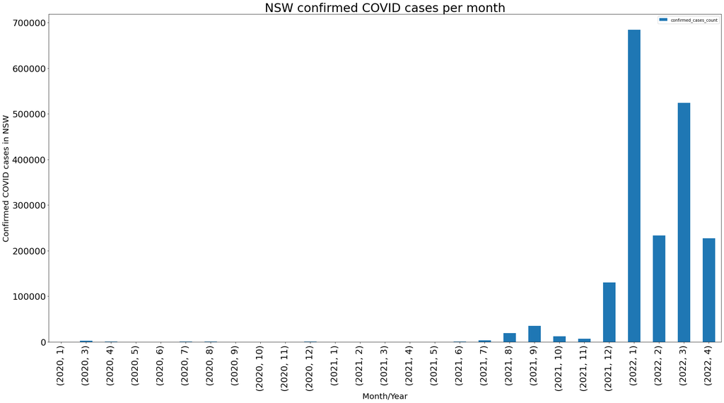

```python
#plotting monthly COVID data
NSW_COVID_df.plot(
    kind='bar',
    legend=True,
    figsize = [30,15],
    fontsize = 22,
)

plt.legend(loc='best')
plt.title('NSW confirmed COVID cases per month', fontdict={'fontsize': 30})
plt.xlabel('Month/Year', fontdict={'fontsize': 20})
plt.ylabel('Confirmed COVID cases in NSW',fontdict={'fontsize':20})
```

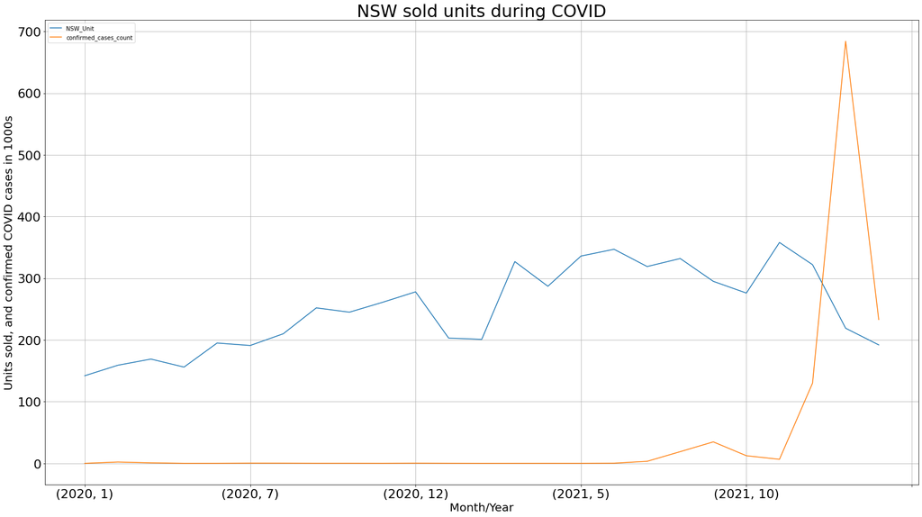

```python
#merging COVID and NSW dataframe
full_df = df5.merge(NSW_COVID_df, on=['YEAR', 'MONTH'], how='inner')
full_df = full_df.groupby(['YEAR', 'MONTH']).sum()
#dropping certain columns which are unused
full_df = full_df.drop(columns = ['DAY', 'NSW_Cost'])
#balancing the graph whilst dividing confirmed cases by 1000
full_df['confirmed_cases_count'] = full_df['confirmed_cases_count']/1000

#plotting the COVID and NSW property to show-case any visual corelation
full_df.plot(
    kind='line',
    subplots=False,
    sharey=True,
    grid = True,
    legend=True,
    figsize = [27.5,15],
    fontsize = 22
)
plt.legend(loc='best')
plt.title('NSW sold units during COVID', fontdict={'fontsize': 30})
plt.xlabel('Month/Year', fontdict={'fontsize': 20})
plt.ylabel('Units sold, and confirmed COVID cases in 1000s',fontdict={'fontsize':20})
```

### **5. Conclusions and Discussion**

When responding to Question 2, 3 and 4, it is clearly demostrable that states such as NSW, Victoria, and Queensland (partially), are leading the housing market boom. NSW and Victoria have been the traditional stronghold and a good indicators of Australian property markets over the last few decades. Queensland market has shown stronger growth probably due to the Olympics Games announced for 2032.

To further enhance the evidence and test our hypothesis, we downloaded and mapped the NSW COVID confirmed cases from the state site. The results shows that although there is evidence of COVID having some impact on the initial sell of properties state wide. NSW COVID peak has been identified to be late December 2021 and January 2022, which has shown to have a dip in the Unit Sell and overall Cost for NSW. Traditionally spring and summer months have always shown strong volatility in the property market. This year though has shown a different trend and thus not entirely rejecting the hypothesis.

### **6. Future analysis on the topic**

We have considered NSW as an indicator of Australian market trending of property market and COVID as a single variable which impacts the property market.

Trends for property and housing markets have a meaure of other variables including;

1. lending rates from banks
2. suburn of the property
3. urban or rural
4. house versus unit market
5. COVID
6. et-al

Analysis of these variables shall be considered to have a deeper understanding of first-time-home-buyer and their buying behaviour. As an example a slashed lending rate by the banks would have resulted in a higher populace to enter the property markets for the first time in 2019 and 2020. Similarly COVID situation and loss of jobs could have inversely impacted the property market. Banks and other lending institues have provided higher percentage of borrowing capability to potential home buyers.

There are clearly multiple variables impacting the housing market in Australia, the list given above are only some further analysis which could be done. Hypothesis and buying behaviour should have an integrated view of all such variables.

### **7. References**

**NSW COVID data** https://data.nsw.gov.au/search/dataset/ds-nsw-ckan-aefcde60-3b0c-4bc0-9af1-6fe652944ec2/details?q=

**Housing Data** https://www.housingdata.gov.au/page/resources/data-sources

**Austrlian Bureau of Stastics** https://www.abs.gov.au/statistics/economy/finance/lending-indicators/feb-2022#data-download

**Python Data Science Handbook** - Jake Vanderplas

**Introduction to Machine Learning with Python** - Andreas C. Muller & Sarah Guido